# Презентация по установки операционной системы

Основы информационой безопасности

Барето Вилиан Мануел

Российский университет дружбы народов, Москва, Россия

21 февраля 2026

# Информация

## Докладчик

- Бврето Вилиан Мануел
- Физико-Математический факультет
- Российский университет дружбы народов
- 1032239248@rudn.ru

# Цель работы

Приобретение практических навыков установки операционной системы на виртуальную машину.

# Выполнение работы

В приложнии VirtualBox создаю новую виртуальную машину. Указываю имя виртуальной машины и добавляю оптический диск.

[figure not shown]

Оптический диск

## Настроики

Указываю обьем памяти и создаю виртуальнный жетский диск.

[figure not shown]

Объем оперативнной памяти

## Настроики

[figure not shown]

Жетский диск

## Настроики

Соглашаюсь с поставленными настройками.

[figure not shown]

Итог

## Настроики

Проверяю подключения диска в носителях образ.

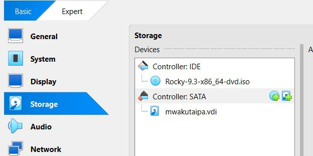

Носители

## Настроики

[figure not shown]

Окно настроек

## Настроики

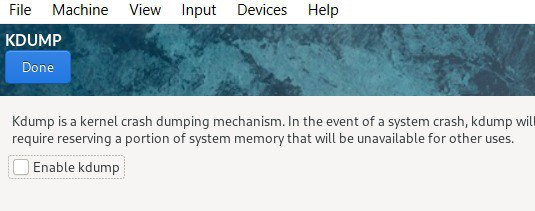

Отключение kdump

## Настроики

[figure not shown]

Создание пользователя

## Настроики

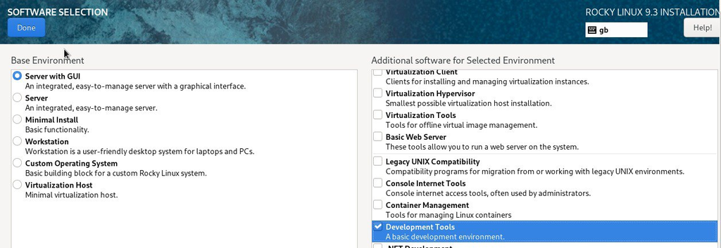

Выбор окружения

## Установка

Затем устанавливаю систему.

[figure not shown]

Установка

## Установка

После завершения установки образ диска пропадет из носителей.

[figure not shown]

Проверка носителей

## Установка

При запуске виртуальной машины появляется окно выбора пользователя.

[figure not shown]

Окно выбора пользователя

## Информация о системе

Запускаю в терминале: dmesg | grep -i “Linux version”, чтобы получить информацию о ядра.

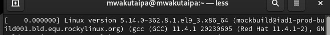

Версия ядра Linux

## Информация о системе

dmesg | grep -i “detected”, чтобы получить информацию о процессоре.

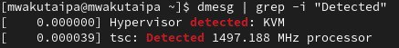

Частота процессора

## Информация о системе

dmesg | grep -i “CPU”, чтобы получить информацию о модели процессора.

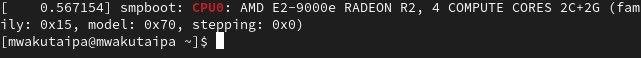

Модель процессора

# Выводы

Я приобрел практические навыки установки операционной системы на виртуальную машину, настройки минимально необходимых для дальнейшей работы сервисов.